# Map

### Damage Proxy Map (Last Updated: 2023-12-29 14:45:31.604577)

[interactive chart not shown]

### % of buildings damaged since 2023-10-07

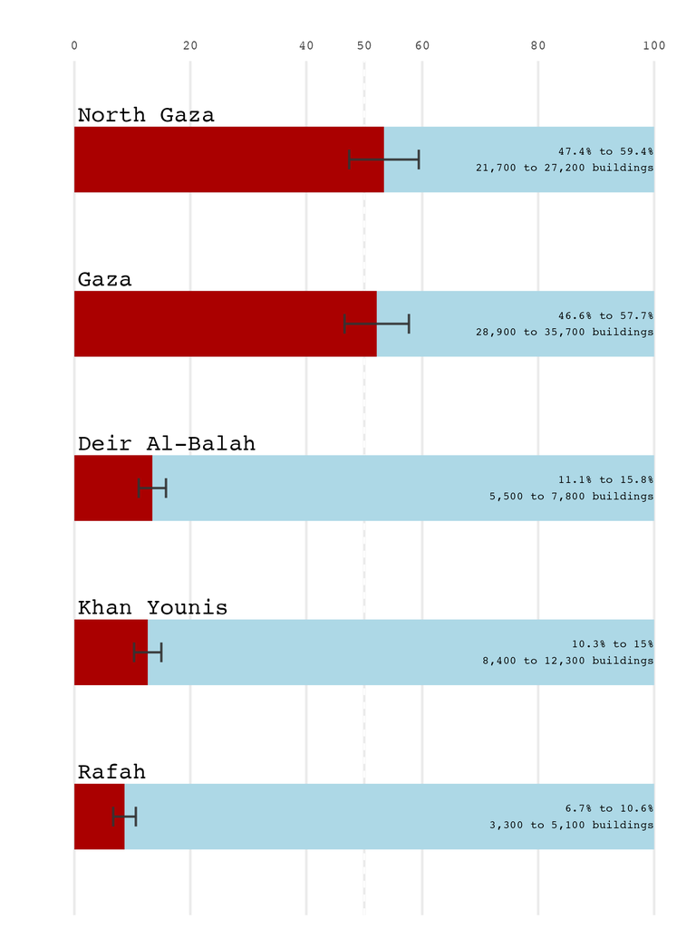

# Data

#### Download

DISCLAIMER: Data provided are provisional and as-is, intended for informational purposes only; we do not guarantee accuracy.

Data last updated: 2023-12-29 14:45:31.76999

[⬇️ 2023-10-12 Damage Data](https://whoiscorey.com/files/cv.pdf)  
[⬇️ 2023-10-17 Damage Data](https://whoiscorey.com/files/cv.pdf)  
[⬇️ 2023-10-23 Damage Data](https://whoiscorey.com/files/cv.pdf)

#### Interpreting the damage maps

The damage maps have two values: 0 and 1.  
- 0 represents no detectable damage  
- 1 represents likely damage in human settlements (cities, towns, villages)

A map of total (aggregate) damage could be produced by simply adding the two maps together and finding pixels with a value of 1.

The damage maps have been clipped to the boundary of the Gaza Strip and have a 40 meter spatial resolution.

Note that these data are preliminary and unvalidated. However, our preliminary comparisons between these damage maps and available high-resolution satellite imagery and/or reported locations of artillery strikes suggest good agreement. As georeferenced damage data become available, we will work to quantitatively assess agreement between our damage maps and other datasets.

#### Loading the damage maps

The images are readable in Geographic Information System software such as Quantum GIS or ArcGIS and most other online mapping platforms.

If you would like to access these data in a format other than `tif`, such as `kml`, `shapefile`, or `geoJSON`, let us know.

#### Attribution

If you use these maps in your reporting, please include the following citation (hyperlinks embedded):

> Source: Damage analysis of Copernicus Sentinel-1 satellite data by [Corey Scher](http://www.whoiscorey.com/) of CUNY Graduate Center and [Jamon Van Den Hoek](https://www.conflict-ecology.org/team#h.p_jXCdhMhBDnGL) of Oregon State University.

… and please share with us links to any published versions of these maps.

#### Distribution

Please do not distribute these files beyond your working group. We are setting up a public-facing website that will host damage maps for broader access.

#### Methods

The damage maps are based on a multi-date analysis of European Space Agency Copernicus Sentinel-1 data. We used a coherent change detection approach, which we presented in a June 2022 [NASA ARSET](https://appliedsciences.nasa.gov/get-involved/training/english/arset-humanitarian-applications-using-nasa-earth-observations) training (Part 1) on mapping urban damage during armed conflict.